# Etude du modèle GPT-2 - Groupe ALOQAS

Dans le cadre de cette SAE, nous allons faire usage du modèle GPT-2, un Large Language Model (LLM) mis au point par OpenAI.

Le modèle génère du texte en se basant sur le contexte et le contenu textuel précédent celui ci. Son principe se rapproche des réseaux de neurones RNN (Recurrent Neural Network) que l'on a pu étudié auparavant au sein de notre formation, ajustant ses paramètres en se basant sur les résultats obtenus aux couches précédentes. Pour cela, le modèle est pré-entrainé sur un large corpus de texte.

A travers ce notebook, nous nous sommes fixés comme objectif de découvrir le modèle GPT-2, d'étudier les différents modules/modèles associés mis à notre disposition par l'API Keras + Tensorflow, de tester ses capacités de génération de texte dans divers cas d'utilisations, d'établir un constat sur les forces, faiblesses et limites de celui-ci.

## Installation de KerasNLP

Pour nos tests sur le modèle GPT-2, nous faisons usage de KerasNLP, une librairie utilisée pour le Natural Language Processing.

Elle constitue une extension de Keras qui est une API de Deep Learning associé à la plateforme de machine learning TensorFlow.

[A propos de Keras NLP](https://keras.io/keras_nlp/)

[A propos de Keras](https://keras.io/about/)

```python
!pip install keras-nlp --upgrade
```

[output not shown]

```python
!pip install git+https://github.com/keras-team/keras-nlp.git -q
```

```
  Installing build dependencies ... done
  Getting requirements to build wheel ... done
  Preparing metadata (pyproject.toml) ... done
```

```python
import os

# Le backend de Keras pouvant supporter jax, tensorflow ou pytorch,
# nous choisissons Tensorflow pour être en accord avec le sujet.
os.environ["KERAS_BACKEND"] = "tensorflow"

import keras_nlp
import tensorflow as tf
import keras_core as keras
import time
```

Nous avons expérimenté avec le code proposé sur Keras afin de réaliser des premiers tests pour découvrir le modèle GPT-2.

[GPT2 Text Generation with KerasNLP](https://keras.io/examples/generative/gpt2_text_generation_with_kerasnlp/)

## Modèle GPT-2

### Généralités

Le modèle GPT-2 est representé par GPT2Backbone, qui est l'architecture de base modulable pour toute utilisation souhaitée. Pour la génération de texte, nous allons utiliser GPT2CausalLM qui est une extension de GPT2Backbone plus orienté vers le langage causal, c'est à dire se basant sur les mots précédents dans la phrase courante pour la production de résultat à la suite.

Il existe différents presets de modèles de GPT-2 composés d'un nombre différents de couches et donc de paramètres.

Pour débuter notre étude, nous utilisons gpt2_base_en qui est un modèle de 12 couches pré-entrainé sur du texte. Il existe aussi d'autres models tels que "gpt2_medium_en", "gpt2_large_en", "gpt2_extra_large_en", faisant usage d'un nombre plus important de couches et de paramètres.

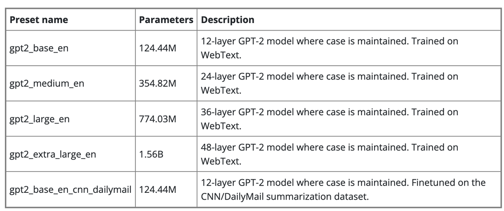

### Modules

GPT-2 possède plusieurs modules sous forme de modèles pré-entrainés, chacuns avec leur propre utilité. Parmi ces modèles, nous pouvons citer le modèle de base GPT2Backbone, le modèle GPT2CausalLM, le tokenizer, les préprocesseurs respectifs.

- `[keras_nlp.models.GPT2Backbone]` - Le modèle de base constituant GPT-2 et son architecture de base. Il est généré avec des paramètres aléatoire et agit comme une base personnalisable selon les besoins.
- `[keras_nlp.models.GPT2CausalLM]` - Le modèle représentant une extension de GPT-2 Backbone, orienté sur le langage causal et permettant la génération de texte. Ce dernier possède une méthode generate() qui va nous permettre de fournir un contenu textuel en entrée et de demander une complétion de ce texte via le modèle GPT-2.
- `[keras_nlp.models.GPT2Tokenizer]` - Le tokenizer transforme le contenu textuel, les chaines de caractères fournies en entiers indices pour chaque séquence de caractères et cela par rapport à leur position dans la phrase.
- `[keras_nlp.models.GPT2Preprocessor]` - Associé à GPT2 Backbone, il permet de rajouter une couche de traitement avant le réseau de neurones principal. Cette couche effectue notamment un tokenizing (expliqué précédemment) et la construction d'un dictionnaire d'identifiants.
- `[keras_nlp.models.GPT2CausalLMPreprocessor]` - Ce préprocesseur est destiné à être utilisé en conjonction avec GPT2 Causal LM, et sert à introduire une couche de traitement du texte avant qu'il soit traité par le réseau de neurones du modèle GPT2.

[A propos des différents modules de GPT-2](https://keras.io/api/keras_nlp/models/gpt2/)